# Supplementary domain trees

## DBLb12

The tree below is not very informative due to the very high level of conservation found in the de novo assembled DBLb12 transcripts. However the DBLb12 transcripts from PFEMP1 domains of Rask et al split into two groups which are equally distant from each other as they are from the tightly clustered severe group. This suggests that the severe DBLb12 cluster could be grouped with those from DC8 as there is just as much variation between DC8 DBLb12 domains as there is between the severe group and DC8 DBLb12 domains.

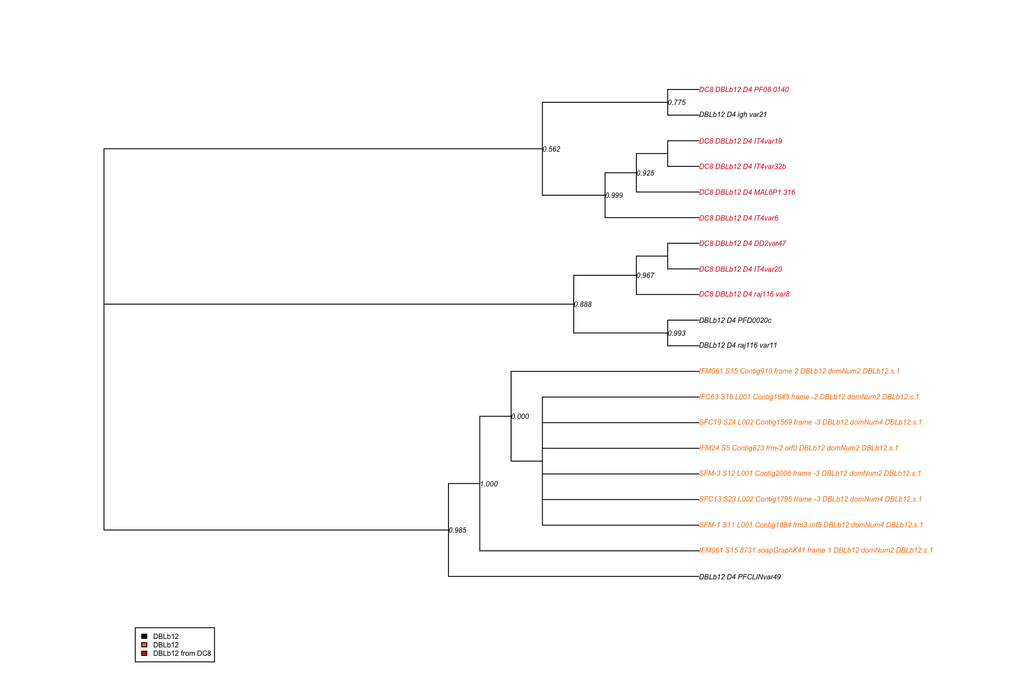

```r
tree <- read.tree("./data/compare_DC8/MA_combined_raskDBLb12_DBLb12s.fasta.phy")

labels <- "black"
labels[grepl("\\.s\\.1", tree$tip.label)] <- "#ff7f00"
labels[grepl("^DC8", tree$tip.label)] <- "#e41a1c"


plot.phylo(tree, type = "phylogram", use.edge.length = FALSE, show.node.label = TRUE,
    cex = 0.5, tip.color = labels, align.tip.label = TRUE)
legend(1, -1, legend = c("DBLb12", "DBLb12", "DBLb12 from DC8"), fill = c("black",
    "#ff7f00", "#e41a1c"), xpd = NA, cex = 0.5)
```

## CIDRb1

The severe CIDRb1 domain clusters together with one DC8 CIDRb1 domain from Rask et al. The remaining CIDRb1 domains from proteins that conatin DC8 in Rask et al are distributed across the remianing CIDRb1 domains from Rask et al and don’t form a disctinct group.

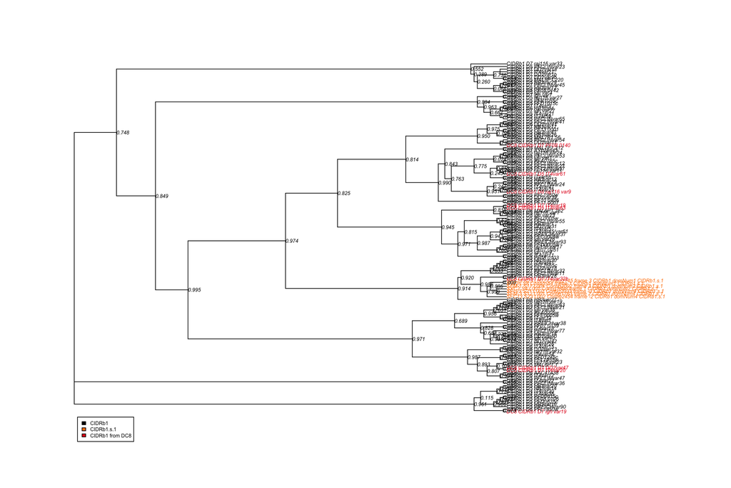

```r
tree <- read.tree("./data/compare_DC8/MA_combined_raskCIDRb1_CIDRb1s.fasta.phy")

labels <- "black"
labels[grepl("\\.s\\.1", tree$tip.label)] <- "#ff7f00"
labels[grepl("^DC8", tree$tip.label)] <- "#e41a1c"


plot.phylo(tree, type = "phylogram", use.edge.length = FALSE, show.node.label = TRUE,
    cex = 0.5, tip.color = labels, align.tip.label = TRUE)
legend(1, -1, legend = c("CIDRb1", "CIDRb1.s.1", "CIDRb1 from DC8"), fill = c("black",
    "#ff7f00", "#e41a1c"), xpd = NA, cex = 0.5)
```